# Scatterplot Exercises

Vamos considerar uma amostra aleatória de finalistas da Maratona de Nova York em 2002. Esse conjunto de dados pode ser encontrado no pacote UsingR. Carregue a biblioteca e, em seguida, carregue o conjunto de dados nym.2002.

|  | place | gender | age | home | time |
| --- | --- | --- | --- | --- | --- |
| 3475 | 3592 | Male | 52 | GBR | 217.4833 |
| 13594 | 13853 | Female | 40 | NY | 272.5500 |
| 12012 | 12256 | Male | 31 | FRA | 265.2833 |
| 10236 | 10457 | Female | 33 | MI | 256.1500 |
| 9476 | 9686 | Male | 33 | NY | 252.2500 |
| 1720 | 1784 | Male | 40 | NJ | 201.9667 |

Exercícios de gráfico de dispersão nº 1 Use dplyr para criar dois novos quadros de dados: masculino e feminino, com os dados de cada gênero. Para os homens, qual é a correlação de Pearson entre idade e tempo para terminar?

```r
cor(males$age,males$time)
```

```
[1] 0.2432273
```

Exercícios de gráfico de dispersão nº 2 Para as mulheres, qual é a correlação de Pearson entre idade e tempo para terminar?

```r
cor(females$age,females$time)
```

```
[1] 0.2443156
```

Exercícios de gráfico de dispersão nº 3 Se interpretarmos estas correlações sem visualizar os dados, concluiríamos que quanto mais velhos ficamos, mais devagar corremos maratonas, independentemente do género. Veja gráficos de dispersão e boxplots de tempos estratificados por faixas etárias (20-25, 25-30, etc.). Depois de examinar os dados, qual é a conclusão mais razoável?

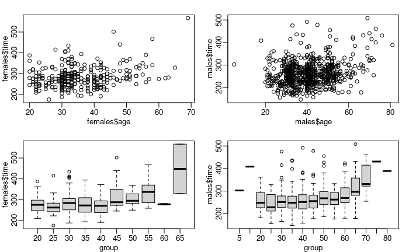